```python
#The packages I'm using:
import pyfftw
import numpy as np
import matplotlib.pyplot as pl
from scipy.integrate import odeint
import scipy as sp
from matplotlib import cm
import scipy.special as spc
from numpy import random
```

# Vegetation Patterns - Code

## Creating the Grid:

- **In the Real Space:**

```python
L0=10**2 # The size of the Grid

N=400 # Number of points I'm using

dx=L0/N # Space between points - X direction
dy=L0/N # Space between points - Y direction

x = np.arange(-L0/2, L0/2, dx) # X axis
y = np.arange(-L0/2, L0/2, dy) # Y axis

X, Y = np.meshgrid(x, y)   # Two Grids with the values of X and Y in every point of the Grid

## Ex: if x=[0,1,2] and y=[0,1,2]
##
##    [0,1,2]    [2,2,2]
##  X=[0,1,2]  Y=[1,1,1]
##    [0,1,2]    [0,0,0]
```

- **In the Fourier Space**

```python
# The Fourier coordinates
kx=2*np.pi*np.fft.fftfreq(N,d=dx)
ky=2*np.pi*np.fft.fftfreq(N,d=dy)

K, L = np.meshgrid(kx, ky) # Two Grids with the values of kx and ky in every point of the Grid

Rk = np.sqrt((K)**2 +(L)**2) # The "radius" of the Fourier coordinates
# Basically:
```

$R_k = |\vec{k}|$

## Time, Parameters and Initial Condition:

```python
dt=0.01
T=20001
ts=np.arange(0,T*dt,dt)

beta0=1
alpha=0.4
delta=17
R=8
q=1

## Initial Condition:
rh0=(np.array([[random.rand() for i in range(N)] for j in range(N)]) -0.5)*0.1 + (beta-alpha)/(beta+alpha*delta)
```

- **Parameters:**

- **Initial condition:**

$\rho_0 = Rand() + \rho^{*}$

*Whereby:* $\rho^{*} = \dfrac{\beta_0-\alpha}{\beta_0 + \alpha\delta},$

*and:*: $Rand() = $ A grid of uniformly distributed random numbers on the interval: $[-0.05,0.05]$

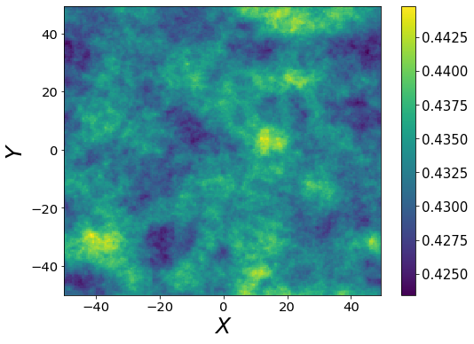

```python
fig
```

## Functions:

### Defining $\hat{G}(\vec{k})$:

$\hat{G}(\vec{k})= 2 \dfrac{J_{1}(|\vec{k}|R)}{|\vec{k}|R}$

- Whereby $J_1(x)$ is the ﬁrst-order Bessel function.

```python
def G_hat(Rk,R):
    G_hat=2*spc.j1(Rk*R)/(Rk*R) #spc.j1() is the bessel function
    G_hat=np.nan_to_num(G_hat, copy=True, nan=1, posinf=None, neginf=None) # Taking into accont that lim x->0 of J1(x)/x = 1
    return G_hat

Gh=G_hat(Rk,R)
```

- $\hat{G}$ is defined in the real space and one can write:

\begin{equation} G(\vec{r}) = \mathscr{F}^{-1} \{ \hat{G}(\vec{k}) \} = \begin{cases} \dfrac{1}{\pi R^2}, & \text{if $|\vec{r}| \leq R$} \\[1ex] 0, & \text{Otherwise}\end{cases} \end{equation}

### Probability of surviving competition:

```python
def r(rho):
    pyfftw.interfaces.cache.enable() # Just optmizing things
    rho_hat=pyfftw.builders.fft2(rho,threads=3) # Taking \rho into the fourier space

    conv = pyfftw.builders.ifft2((Gh*rho_hat()),threads=3) # The convolution part

    return 1/(delta*conv().real +1) #Substituting in the function
```

Let:

${\displaystyle \tilde{\rho} = \int G(|\vec{r} - \vec{a}'|) \rho \; d\vec{a}.}$

Thus,

${\displaystyle \mathscr{F}\{\tilde{\rho}\} = \hat{G}(\vec{k}) \mathscr{F}\{\rho \}}$

Therfore, on the first 3 lines of the code we are obtaining $\tilde{\rho}$:

${\displaystyle \tilde{\rho} = \mathscr{F}^{-1} \big\{\hat{G}(\vec{k}) \mathscr{F}\{\rho \} \big \} }$

Then, in the last line of code we substitute $\tilde{\rho}$ in:

$\displaystyle r(\tilde{\rho},\delta) = \dfrac{1}{(1 + \delta \tilde{\rho})^{q}}$

### The time derivative:

```python
def Run_PDE(rho,K,L):

    return beta*r(rho)*rho*(1-rho)-alpha*rho
```

**Basically:**

$ {\displaystyle \dfrac{\partial \rho}{\partial t} = \beta_0 r(\tilde{\rho},\delta) \rho (1-\rho) - \alpha \rho}$

## Runing in time:

```
Time = 0
```

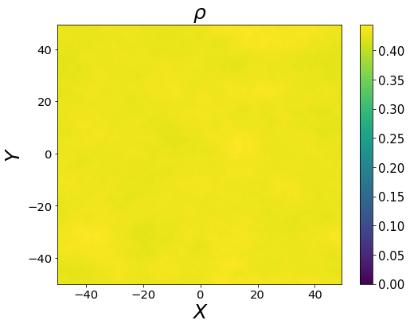

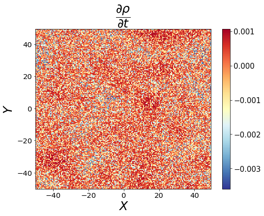

```
Time = 5000
```

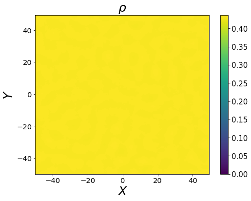

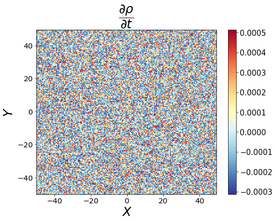

```
Time = 10000
```

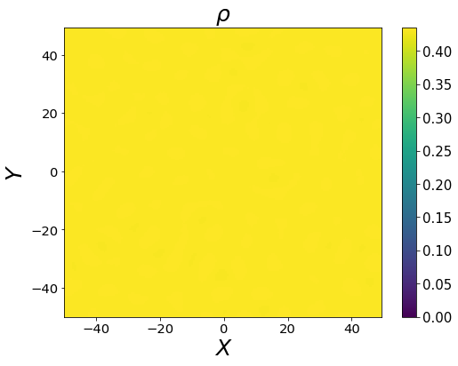

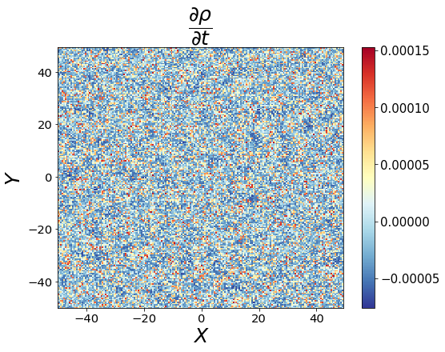

```
Time = 15000
```

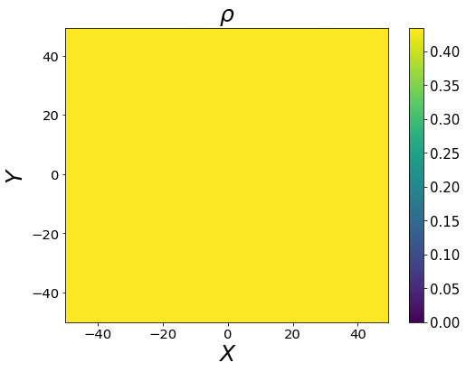

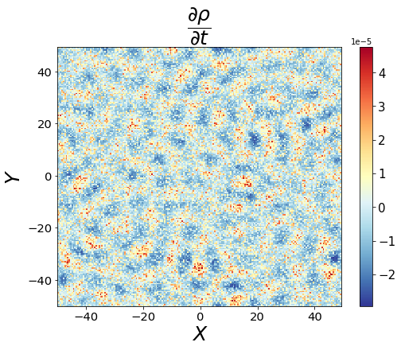

```
Time = 20000
```

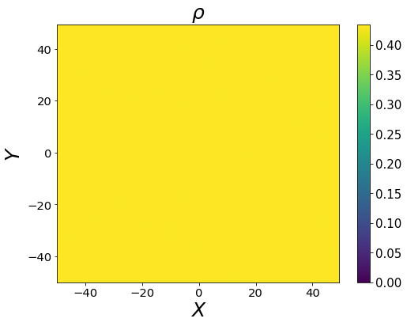

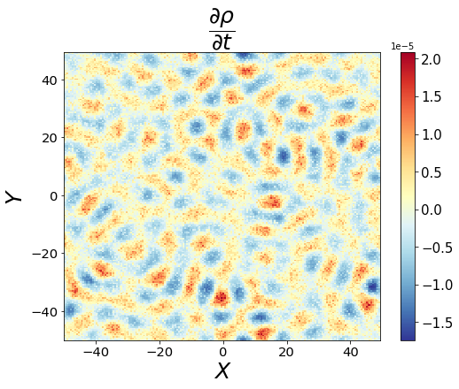

```python
import warnings; warnings.simplefilter('ignore')

uo=u0 # Setting the initial condition as the first step
for t in range(len(ts)):

    u=uo + dt*Run_PDE(uo,K,L) #Euler algorithm



    if t % 5000 == 0: #Plotting
        print('Time = '+str(t))
        fig1, ax = pl.subplots(figsize=(8, 6))
        pl.pcolormesh(X,Y,r(u),cmap='viridis',vmin=0)
        cbar=pl.colorbar()

        cbar.ax.tick_params(labelsize=15)

        ax.tick_params(labelsize=14.8)


        ax.set_ylabel("$Y$",fontsize=25, fontname="Arial")
        ax.set_xlabel("$X$",fontsize=25, fontname="Arial")

        ax.set_title(r'$\rho$',fontsize=25 )

        fig2, ax = pl.subplots(figsize=(8, 6))
        pl.pcolormesh(X,Y,Run_PDE(uo,K,L),cmap='RdYlBu_r')
        cbar=pl.colorbar()

        cbar.ax.tick_params(labelsize=15)

        ax.tick_params(labelsize=14.8)
        ax.set_title(r'$\dfrac{\partial \rho}{\partial t}$',fontsize=25 )
        ax.set_ylabel("$Y$",fontsize=25, fontname="Arial")
        ax.set_xlabel("$X$",fontsize=25, fontname="Arial")
        pl.show()

    uo=u
```

**The patterns apper in the derivative but never in the grid!!** 😓

- If we go far enough in time:

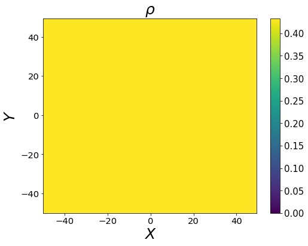

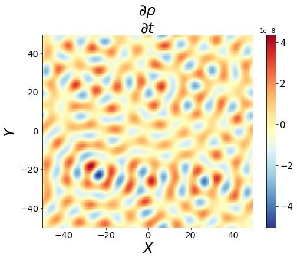

```python
### Time = 200000:
```

The derivative keeps getting lower and lower and the system goes to the homogeneous state 😭